# Insights into the greenhouse gas emissions in the euro area and G20 countries

Aleksandra Dacko

2025-02-09

The presentation should be about your own analysis on global greenhouse gas (GHG) emissions covering the euro area and the G20 countries with a focus on the following aspects: Evolution of the overall and annual growth of GHG emissions between 1999 – 2023; Sectoral contributions to the overall the GHG emissions; Relationship between the GDP growth and GHG emissions and Any other interesting insights that you may wish to share and its possible linkage with international developments.

## Evolution of the overall and annual growth of GHG emissions between 1999 – 2023

```r
require(ggplot2)
require(readxl)
library(tidyverse)
#Clean the data by removing completely empty rows
EDGAR_2024_totals = read_excel("data/EDGAR_2024_GHG_booklet_2024.xlsx", sheet = "GHG_totals_by_country") %>% dplyr::filter(rowSums(is.na(.)) != ncol(.))

EDGAR_2024_sectors = read_excel("data/EDGAR_2024_GHG_booklet_2024.xlsx", sheet = "GHG_by_sector_and_country") %>% dplyr::filter(rowSums(is.na(.)) != ncol(.))

#GDP (constant 2015 US$)
gdp_data=read.csv2("./data/world_bank_data.csv", sep=",",check.names=FALSE) %>% select(-69) %>% select(-`Indicator Code`) %>% tidyr::pivot_longer(cols=dplyr::matches("^\\d{4}$"), names_to = "Time period",values_to='GDP') %>%
  dplyr::mutate(`Time period` = as.Date(`Time period`, format="%Y") %>%
           lubridate::year(.)) %>%
  dplyr::filter(`Time period`>="1999")


colScale1=scale_color_manual(values = c("#003899","#ff4b00","#FFB400","#007816","#00B1EA"))
colScale1b=scale_fill_manual(values = c("#003899","#ff4b00","#FFB400","#007816","#00B1EA"))
colScale2=scale_fill_manual(values = c("#003899","#FFB400","#ff4b00","#65b800","#00B1EA","#007816","#8139C6","#5C5C5C"))
euro_area_countries_3letter=
  c("AUT",
    "BEL",
    "HRV",
    "CYP",
    "EST",
    "FIN",
    "FRA",
    "DEU",
    "GRC",
    "IRL",
    "ITA",
    "LVA",
    "LTU",
    "LUX",
    "MLT",
    "NLD",
    "PRT",
    "SVK",
    "SVN",
    "ESP"
    )

# Fixed composition at the 2023
G20_countries_3letter=
  c("EU27",
    #"DEU",
    #"FRA",
    "ARG",
    "AUS",
    "BRA",
    "CAN",
    "CHN",
    "IND",
    "IDN",
    #"ITA",
    "JPN",
    "MEX",
    "RUS",
    "SAU",
    "ZAF",
    "KOR",
    "TUR",
    "GBR",
    "USA"
    )
```

```r
require(treemapify)
```

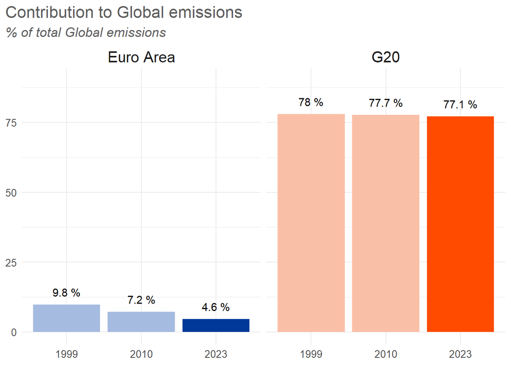

```r
G20_summary=EDGAR_2024_totals %>%
  dplyr::filter(`EDGAR Country Code` %in% G20_countries_3letter) %>%
  tidyr::pivot_longer(cols =dplyr::matches("^\\d{4}$"), names_to = "Time period",values_to='GHG Total') %>%
  dplyr::mutate(`Time period` = as.Date(`Time period`, format="%Y") %>%
           lubridate::year(.)) %>%
  arrange(`Time period`,`GHG Total`) %>% group_by(`Time period`) %>%
  mutate("Group Total"=sum(`GHG Total`)) %>%
  mutate("Group Name"='G20') %>% mutate(`Contr_to_tot`=`GHG Total`/`Group Total`*100)

EA_summary=EDGAR_2024_totals %>%
  dplyr::filter(`EDGAR Country Code` %in% euro_area_countries_3letter) %>%
  tidyr::pivot_longer(cols =dplyr::matches("^\\d{4}$"), names_to = "Time period",values_to='GHG Total') %>%
  dplyr::mutate(`Time period` = as.Date(`Time period`, format="%Y") %>%
           lubridate::year(.))  %>%
  arrange(`Time period`,`GHG Total`) %>%
  group_by(`Time period`) %>%
  mutate("Group Total"=sum(`GHG Total`)) %>%
  mutate("Group Name"='Euro Area') %>% mutate(Country=case_when(`EDGAR Country Code`=='ITA' ~ "Italy",
                           `EDGAR Country Code`=='FRA' ~ "France",
                           `EDGAR Country Code`=='ESP' ~ "Spain",
                           TRUE ~ Country)) %>% mutate(`Contr_to_tot`=`GHG Total`/`Group Total`*100)

GLOBAL_summary=EDGAR_2024_totals %>%
  dplyr::filter(`EDGAR Country Code`=='GLOBAL TOTAL') %>%
  tidyr::pivot_longer(cols =dplyr::matches("^\\d{4}$"), names_to = "Time period",values_to='Global Total') %>%
  dplyr::mutate(`Time period` = as.Date(`Time period`, format="%Y") %>%
           lubridate::year(.)) %>% select(`Time period`,`Global Total`)

data_summary=rbind(G20_summary,EA_summary) %>% left_join(.,GLOBAL_summary,by = join_by(`Time period`)) %>%
  group_by(`Time period`) %>%                        # Group rows by Time
    mutate(contribution = format(round(`Group Total` / `Global Total` * 100,1),nsmall=1)) %>%  # Compute percentage per group
    ungroup() %>% select(`Group Name`,`Time period`,`contribution`) %>% dplyr::distinct() %>% dplyr::filter(`Time period` %in% c(1999,2010,2023)) %>% mutate(YearType=case_when(`Time period` == 2023 & `Group Name`=='Euro Area' ~ "LatestEA",`Time period` != 2023 & `Group Name`=='Euro Area' ~ "PreviousEA",
                                                                                                                                                                                `Time period` == 2023 & `Group Name`=='G20'~"LatestG20", `Time period`!= 2023 & `Group Name`=='G20' ~ "PreviousG20", ))


data_summary$`Time period`=as.factor(data_summary$`Time period`)
data_summary$`contribution`=as.numeric(data_summary$`contribution`)

#### Plot 1 ####
ggplot(data_summary, aes(x=`Time period`,`contribution`,fill=`YearType`))+
      geom_bar(position="dodge",stat="identity",show.legend = FALSE)+
  geom_text(aes(label = paste(`contribution`, "%"),show.legend = FALSE), vjust = -1)+
  facet_grid(~`Group Name`)+
  theme_minimal()+
  ylim(c(0,90))+
  theme(legend.position = "bottom",
        text = element_text(color = "#5C5C5C", size=13),
        legend.title=element_blank(),
        legend.margin = margin(t = -15),
        axis.title.y =element_blank(),
        axis.title.x =element_blank(),
        axis.text=element_text(size=10),
        plot.title = element_text(size = 16),
        plot.subtitle = element_text(face= "italic",size = 13),
        strip.text.x = element_text(size = 15),
        plot.title.position = "plot",plot.caption.position ="plot" )+scale_fill_manual(values = c("PreviousEA" = "#a6bbe0", "LatestEA" = "#003899", "LatestG20" = "#ff4b00", "PreviousG20"="#fac0a7")) +labs(title="Contribution to Global emissions",subtitle = "% of total Global emissions")
```

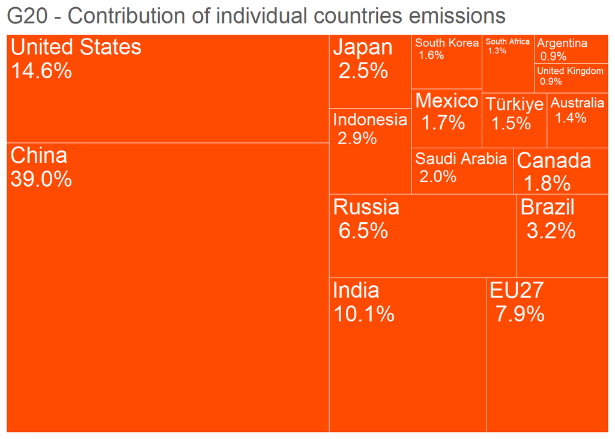

```r
#### Plot 2 ####
G20_summary %>% dplyr::filter(`Time period`=="2023") %>% ggplot(., aes(area = `Contr_to_tot`,fill=`Group Name`,
                                               label=paste(`Country`,"\n",paste0(format(round(`Contr_to_tot`,1),nsmall = 1),"%") ,sep="")),show.legend = FALSE) +
  geom_treemap(colour ="white",show.legend = FALSE ) +
  geom_treemap_text(colour = "white",place = "topleft", reflow = F,grow = FALSE)+
  theme(legend.position = "bottom",
        text = element_text(color = "#5C5C5C"),
        legend.title=element_blank(),
        legend.text = element_text(size=12),
        legend.margin = margin(t = -15),
        axis.title.y =element_text(size=15),
        axis.text=element_text(size=11),
        plot.title = element_text(size = 18),
        plot.subtitle = element_text(face= "italic",size = 12),
        plot.title.position = "plot",plot.caption.position ="plot" )+scale_fill_manual(values = c("#ff4b00"))+
  ggtitle("G20 - Contribution of individual countries emissions")
```

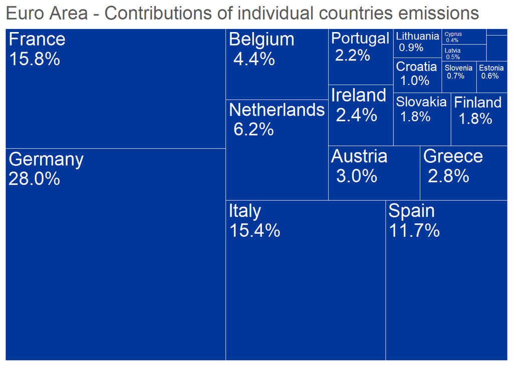

```r
#### Plot 3 ####
EA_summary %>% dplyr::filter(`Time period`=="2023")   %>% ggplot(., aes(area = `Contr_to_tot`,fill=`Group Name`,
                                                                        label=paste(trimws(`Country`),"\n",paste0(format(round(`Contr_to_tot`,1),nsmall = 1),"%") ,sep="")),show.legend = FALSE) +
  geom_treemap(colour ="white",show.legend = FALSE ) +
  geom_treemap_text(colour = "white",place = "topleft", reflow = F,grow = FALSE)+
  theme(legend.position = "bottom",
        text = element_text(color = "#5C5C5C"),
        legend.title=element_blank(),
        legend.text = element_text(size=12),
        legend.margin = margin(t = -15),
        axis.title.y =element_text(size=15),
        axis.text=element_text(size=11),
        plot.title = element_text(size = 18),
        plot.subtitle = element_text(face= "italic",size = 12),
        plot.title.position = "plot",plot.caption.position ="plot" )+scale_fill_manual(values = c("#003899"))+
  ggtitle("Euro Area - Contributions of individual countries emissions")
```

```r
require(IndexNumber)
```

```r
euro_area_row=EDGAR_2024_totals %>%
  dplyr::filter(`EDGAR Country Code` %in% euro_area_countries_3letter) %>%
  dplyr::summarise(.,across(where(is.character), ~"Euro Area"),
                      across(where(is.numeric), sum),)  %>%
  tidyr::pivot_longer(cols =dplyr::matches("^\\d{4}$"), names_to = "Time period",values_to='GHG Total') %>%
  dplyr::mutate(`Time period` = as.Date(`Time period`, format="%Y") %>%
           lubridate::year(.)) %>%
  mutate("2015"=3009.534)
g20_row=EDGAR_2024_totals %>%
  dplyr::filter(`EDGAR Country Code` %in% G20_countries_3letter) %>%
  dplyr::summarise(.,across(where(is.character), ~"G20"),
                      across(where(is.numeric), sum),) %>%
  tidyr::pivot_longer(cols =dplyr::matches("^\\d{4}$"), names_to = "Time period",values_to='GHG Total') %>%
  dplyr::mutate(`Time period` = as.Date(`Time period`, format="%Y") %>%
           lubridate::year(.)) %>%
  mutate("2015"=37833.252)

data_chart1=rbind(euro_area_row,g20_row) %>%
  dplyr::filter(`Time period`>="1999") %>%
  dplyr::group_by(Country) %>%
  dplyr::arrange(`Time period`) %>%
  dplyr::mutate(Diff_year = `Time period` - lag(`Time period`),
         Diff_growth = `GHG Total` - lag(`GHG Total`),
         Rate_percent = (Diff_growth /lag(`GHG Total`)) * 100,
         GHG_index_1999 = IndexNumber::index.number.serie(`GHG Total`,name="GHG Total") %>% dplyr::pull("Index number"),
         GHG_index_2015=`GHG Total`/`2015`*100) %>%
  ungroup()
```

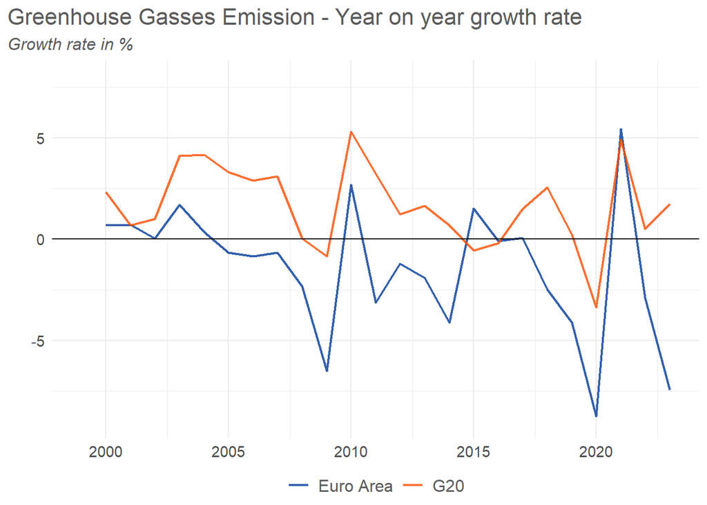

```r
data_chart1 %>% na.omit()%>%
  ggplot(mapping = aes(x=`Time period`,y=Rate_percent,color = Country)) +
  geom_line(linewidth = 0.85,alpha =0.8)+
  geom_hline(yintercept=0)+
  ggtitle("Greenhouse Gasses Emission - Year on year growth rate", subtitle = "Growth rate in %")+
  theme_minimal()+
  theme(legend.position = "bottom",
        text = element_text(color = "#5C5C5C"),
        legend.title=element_blank(),
        legend.text = element_text(size=12),
        legend.margin = margin(t = -15),
        axis.title.y =element_text(size=15),
        axis.text=element_text(size=11),
        plot.title = element_text(size = 16),
        plot.subtitle = element_text(face= "italic",size = 12),
        plot.title.position = "plot",plot.caption.position ="plot" )+colScale1+
  xlim(c(1999,2023))+
  ylim(c(-9,8))+
  xlab("")+
  ylab("")
```

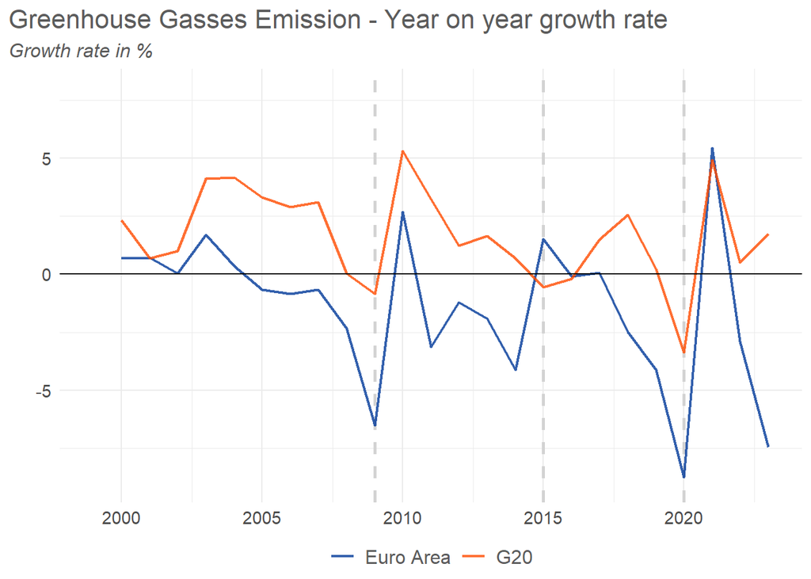

```r
data_chart1 %>% na.omit()%>%
  ggplot(mapping = aes(x=`Time period`,y=Rate_percent,color = Country)) +
  geom_vline(xintercept = 2020, linetype = "dashed", color = "lightgrey", size = 1)+
  geom_vline(xintercept = 2009, linetype = "dashed", color = "lightgrey", size = 1)+
  geom_vline(xintercept = 2015, linetype = "dashed", color = "lightgrey", size = 1)+
  geom_line(linewidth = 0.85,alpha =0.8)+
  geom_hline(yintercept=0)+
  ggtitle("Greenhouse Gasses Emission - Year on year growth rate", subtitle = "Growth rate in %")+
  theme_minimal()+
  theme(legend.position = "bottom",
        text = element_text(color = "#5C5C5C"),
        legend.title=element_blank(),
        legend.text = element_text(size=12),
        legend.margin = margin(t = -15),
        axis.title.y =element_text(size=15),
        axis.text=element_text(size=11),
        plot.title = element_text(size = 16),
        plot.subtitle = element_text(face= "italic",size = 12),
        plot.title.position = "plot",plot.caption.position ="plot" )+colScale1+
  xlim(c(1999,2023))+
  ylim(c(-9,8))+
  xlab("")+
  ylab("")
```

```r
data_chart1 %>% filter(`Time period`<=2015 & `Time period`>=2010) %>% group_by(Country) %>% mutate(corr=cor(`Time period`, `GHG_index_1999`)) %>% head(2)
```

```
## # A tibble: 2 × 11
## # Groups:   Country [2]
##   `EDGAR Country Code` Country   `Time period` `GHG Total` `2015` Diff_year
##   <chr>                <chr>             <dbl>       <dbl>  <dbl>     <dbl>
## 1 Euro Area            Euro Area          2010       3294.  3010.         1
## 2 G20                  G20                2010      35580. 37833.         1
## # ℹ 5 more variables: Diff_growth <dbl>, Rate_percent <dbl>,
## #   GHG_index_1999 <dbl>, GHG_index_2015 <dbl>, corr <dbl>
```

```r
data_chart1 %>% filter(`Time period`<=2015) %>% group_by(Country) %>% mutate(corr=cor(`Time period`, `GHG_index_1999`)) %>% head(2)
```

```
## # A tibble: 2 × 11
## # Groups:   Country [2]
##   `EDGAR Country Code` Country   `Time period` `GHG Total` `2015` Diff_year
##   <chr>                <chr>             <dbl>       <dbl>  <dbl>     <dbl>
## 1 Euro Area            Euro Area          1999       3468.  3010.        NA
## 2 G20                  G20                1999      27530. 37833.        NA
## # ℹ 5 more variables: Diff_growth <dbl>, Rate_percent <dbl>,
## #   GHG_index_1999 <dbl>, GHG_index_2015 <dbl>, corr <dbl>
```

```r
data_chart1 %>% filter(`Time period`>2015) %>% group_by(Country) %>% mutate(corr=cor(`Time period`, `GHG_index_1999`)) %>% head(2)
```

```
## # A tibble: 2 × 11
## # Groups:   Country [2]
##   `EDGAR Country Code` Country   `Time period` `GHG Total` `2015` Diff_year
##   <chr>                <chr>             <dbl>       <dbl>  <dbl>     <dbl>
## 1 Euro Area            Euro Area          2016       3007.  3010.         1
## 2 G20                  G20                2016      37756. 37833.         1
## # ℹ 5 more variables: Diff_growth <dbl>, Rate_percent <dbl>,
## #   GHG_index_1999 <dbl>, GHG_index_2015 <dbl>, corr <dbl>
```

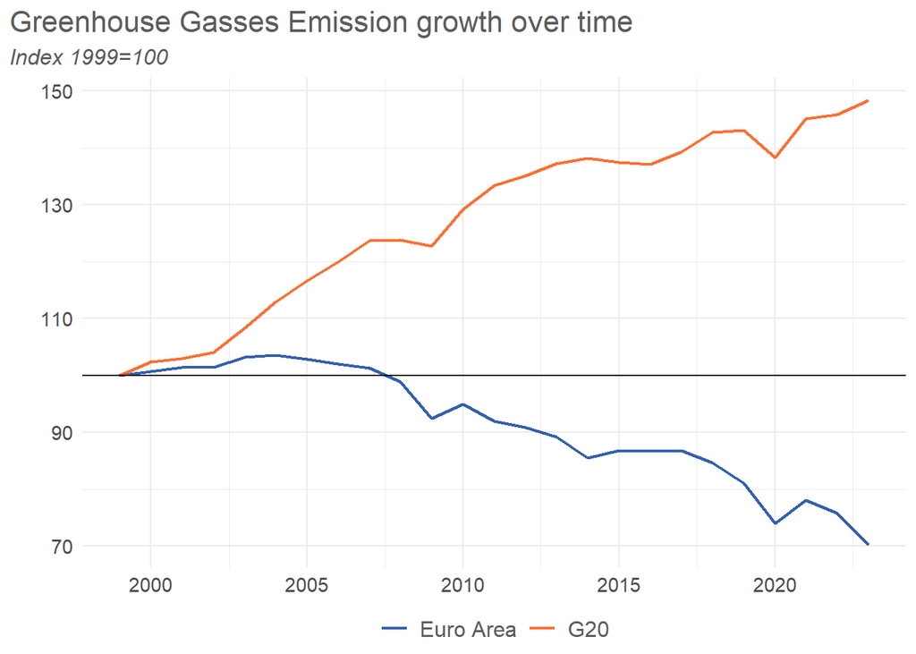

```r
data_chart1%>%
  ggplot(mapping = aes(x=`Time period`,y=`GHG_index_1999`,color = Country)) +
  geom_line(linewidth = 0.85,alpha =0.8)+
  geom_hline(yintercept=100)+

  ggtitle("Greenhouse Gasses Emission growth over time", subtitle = "Index 1999=100")+
  theme_minimal()+
  theme(legend.position = "bottom",
        text = element_text(color = "#5C5C5C"),
        legend.title=element_blank(),
        legend.text = element_text(size=12),
        legend.margin = margin(t = -15),
        axis.title.y =element_text(size=15),
        axis.text=element_text(size=11),
        plot.title = element_text(size = 16),
        plot.subtitle = element_text(face= "italic",size = 12),
        plot.title.position = "plot",plot.caption.position ="plot" )+colScale1+
  xlim(c(1999,2023))+
  xlab("")+
  ylab("")
```

## Sectoral contributions to the overall the GHG emissions

```r
data_chart2_g20=EDGAR_2024_sectors %>%
  dplyr::filter(`EDGAR Country Code` %in% G20_countries_3letter) %>% mutate_at(vars(matches("^\\d{4}$")), ~replace(., is.na(.), 0)) %>% group_by(`Sector`) %>%
  dplyr::summarise(across(where(is.numeric), sum) ) %>% mutate(Country="G20") %>%
  tidyr::pivot_longer(cols =dplyr::matches("^\\d{4}$"), names_to = "Time period",values_to='GHG Total') %>%
  dplyr::mutate(`Time period` = as.Date(`Time period`, format="%Y") %>%
           lubridate::year(.)) %>%
  dplyr::filter(`Time period`>="1999") %>% ungroup() %>%
  group_by(`Time period`) %>%                        # Group rows by Time
    mutate(contribution = `GHG Total` / sum(`GHG Total`) * 100) %>%  # Compute percentage per group
    dplyr::group_by(Sector) %>%
  dplyr::arrange(`Time period`) %>%
  dplyr::mutate(
         Diff_growth = `GHG Total` - lag(`GHG Total`),
         Rate_percent = (Diff_growth /lag(`GHG Total`)) * 100)

 label_data_g20 <- data_chart2_g20 %>%
  group_by(Sector) %>%
  summarize(
    start_time = min(`Time period`),
    mid_period = 2015,
    end_time = max(`Time period`),
    start_value = round(`contribution`[which.min(`Time period`)],2),
    mid_value =round(`contribution`[which(`Time period`==2015)],2),
    end_value = round(`contribution`[which.max(`Time period`)],2)
  )

data_chart2_euro_area=EDGAR_2024_sectors %>%
  dplyr::filter(`EDGAR Country Code` %in% euro_area_countries_3letter) %>% mutate_at(vars(matches("^\\d{4}$")), ~replace(., is.na(.), 0)) %>% group_by(`Sector`)  %>%
  dplyr::summarise(across(where(is.numeric), sum)) %>% mutate(Country="Euro area") %>%
  tidyr::pivot_longer(cols =dplyr::matches("^\\d{4}$"), names_to = "Time period",values_to='GHG Total') %>%
  dplyr::mutate(`Time period` = as.Date(`Time period`, format="%Y") %>%
           lubridate::year(.)) %>%
  dplyr::filter(`Time period`>="1999") %>% ungroup() %>%
  group_by(`Time period`) %>%                        # Group rows by Time
  mutate(contribution = `GHG Total` / sum(`GHG Total`) * 100) %>%  # Compute percentage per group
    dplyr::group_by(Sector) %>%
  dplyr::arrange(`Time period`) %>%
  dplyr::mutate(
         Diff_growth = `GHG Total` - lag(`GHG Total`),
         Rate_percent = (Diff_growth /lag(`GHG Total`)) * 100)

label_data_euro_area <- data_chart2_euro_area %>%
  group_by(Sector) %>%
  summarize(
    start_time = min(`Time period`),
    mid_period = 2015,
    end_time = max(`Time period`),
    start_value = round(`contribution`[which.min(`Time period`)],2),
    mid_value =round(`contribution`[which(`Time period`==2015)],2),
    end_value = round(`contribution`[which.max(`Time period`)],2)
  )
```

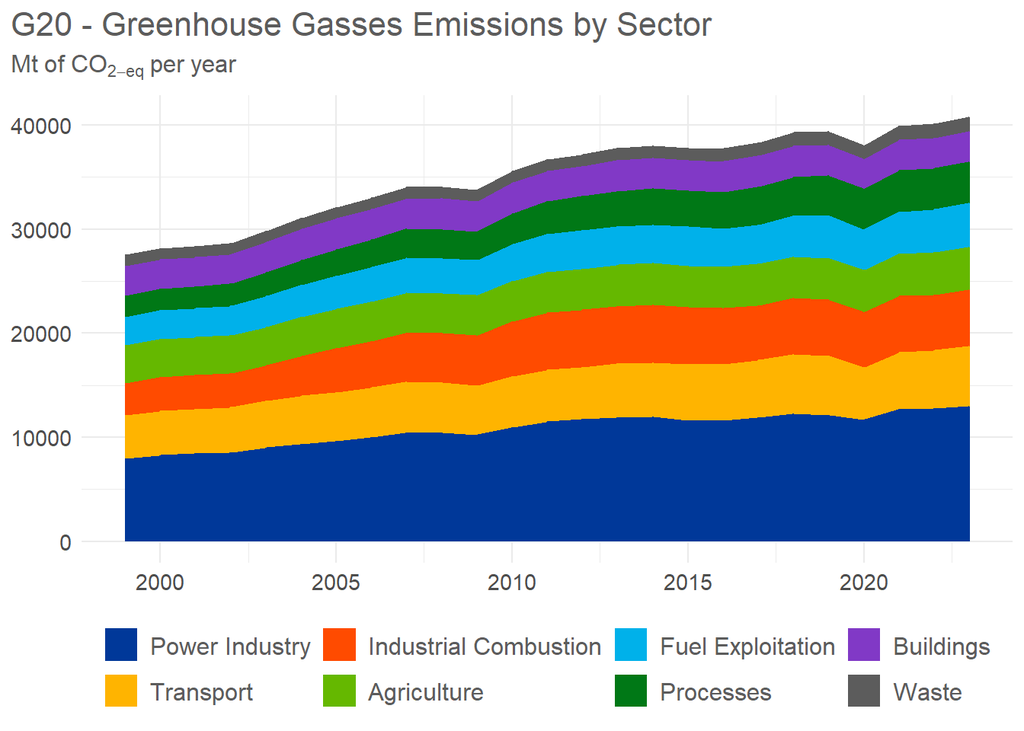

```r
colScale2=scale_fill_manual(values = c("#5C5C5C","#8139C6","#007816","#00B1EA","#65b800","#ff4b00","#FFB400","#003899"))
data_chart2_g20$Sector <- factor(data_chart2_euro_area$Sector, levels = c("Waste","Buildings" ,"Processes","Fuel Exploitation",  "Agriculture","Industrial Combustion" ,"Transport" ,  "Power Industry"))


data_chart2_g20  %>%
  mutate(Sector = fct_reorder(Sector, `GHG Total`, .fun = sum, .desc = FALSE)) %>% ggplot(., aes(x=`Time period`, y=`GHG Total`, fill=Sector)) +
      geom_area()+ theme_minimal()+
  theme(legend.position = "bottom",
        text = element_text(color = "#5C5C5C"),
        legend.title=element_blank(),
        legend.text = element_text(size=12),
        axis.title.y =element_blank(),
        axis.title.x = element_blank(),
        axis.text=element_text(size=11),
        plot.title = element_text(size = 16),
        plot.subtitle = element_text(face= "italic",size = 12),
        plot.title.position = "plot",plot.caption.position ="plot" )+
  colScale2+labs(title = "G20 - Greenhouse Gasses Emissions by Sector", subtitle = expression(Mt~of~CO[2-eq]~per~year))+
  guides(fill = guide_legend(reverse = TRUE))
```

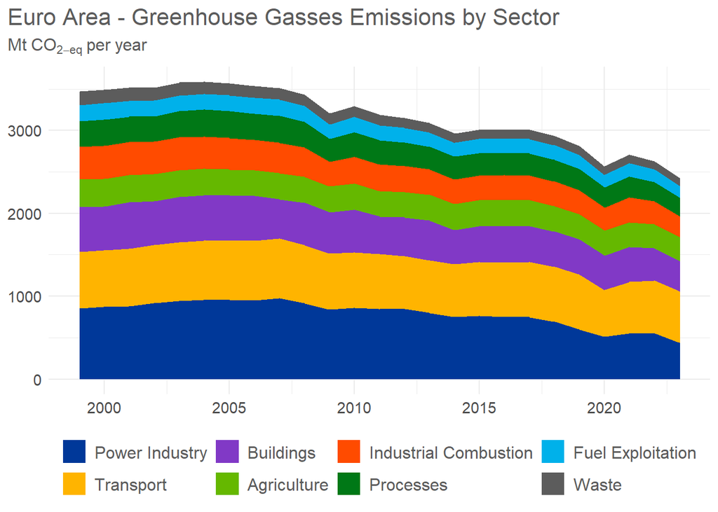

```r
out=data_chart2_euro_area  %>%
  mutate(Sector = fct_reorder(Sector, `GHG Total`, .fun = sum, .desc = FALSE))

colScale2=scale_fill_manual(values = c("#5C5C5C","#00B1EA","#007816","#ff4b00","#65b800","#8139C6","#FFB400","#003899"))

data_chart2_euro_area$Sector <- factor(data_chart2_euro_area$Sector, levels = c("Waste","Fuel Exploitation","Processes","Industrial Combustion",  "Agriculture","Buildings","Transport" ,  "Power Industry"))

data_chart2_euro_area  %>% select(Sector,`GHG Total` ,`Time period`)%>%
  mutate(Sector = fct_reorder(Sector, `GHG Total`, .fun = sum, .desc = FALSE)) %>% ggplot(., aes(x=`Time period`, y=`GHG Total`, fill=Sector)) +
      geom_area()+ theme_minimal()+
  theme(legend.position = "bottom",
        text = element_text(color = "#5C5C5C"),
        legend.title=element_blank(),
        legend.text = element_text(size=12),
        axis.title.y =element_blank(),
        axis.title.x = element_blank(),
        axis.text=element_text(size=11),
        plot.title = element_text(size = 16),
        plot.subtitle = element_text(face= "italic",size = 12),
        plot.title.position = "plot",plot.caption.position ="plot" )+
  labs(title = "Euro Area - Greenhouse Gasses Emissions by Sector", subtitle = expression( Mt~CO[2-eq]~per~year))+
  colScale2+
  guides(fill = guide_legend(reverse = TRUE))
```

## Relationship between the GDP growth and GHG emissions

https://data.worldbank.org/indicator/NY.GDP.MKTP.KD?end=2023&start=1960&view=chart - GDP

```r
gdp_data$GDP=as.numeric(gdp_data$GDP)

chart_3_data_ea=gdp_data %>% dplyr::filter(`Country Code`=="EMU") %>% group_by(`Time period`) %>% summarise(GDP=sum(GDP)) %>% mutate(Country="Euro Area") %>% mutate("1999"=9.672973e+12)
chart_3_data=gdp_data %>%
  dplyr::filter(`Country Code` %in% c(G20_countries_3letter,"EUU")) %>% mutate(`Country Code`= case_when(`Country Code`=="EUU"~"EU27", .default = `Country Code`)) %>% group_by(`Time period`) %>% summarise(GDP=sum(GDP)) %>% mutate(Country="G20") %>%mutate("1999"=4.060811e+13)  %>% rbind(chart_3_data_ea) %>%
  group_by(Country) %>% mutate(GDP_index_1999=`GDP`/`1999`*100) %>% select(-`1999`)

#EMU euro area
#EUU  European union

data_chart3=data_chart1 %>% select(Country,`Time period`,`GHG Total`,GHG_index_1999) %>%
  left_join(.,chart_3_data,by = c("Country"="Country","Time period"="Time period")) %>% pivot_longer(.,cols=c(GHG_index_1999,GDP_index_1999), names_to = "Index", values_to = "Index value")


 a= data_chart3 %>% filter(`Country`=='Euro Area')  %>% filter(`Index`=='GHG_index_1999') %>% pull(`GHG Total`
)
 b= data_chart3 %>% filter(`Country`=='Euro Area')  %>% filter(`Index`=='GDP_index_1999') %>% pull(`GDP`
)
overall_ea=cor(a,b)

a= data_chart3 %>% filter(`Country`=='Euro Area') %>% filter(`Time period`<2010)  %>% filter(`Index`=='GHG_index_1999') %>% pull(`GHG Total`
)
 b= data_chart3 %>% filter(`Country`=='Euro Area') %>% filter(`Time period`<2010)   %>% filter(`Index`=='GDP_index_1999') %>% pull(`GDP`
)
till_2009_ea=cor(a,b)

a= data_chart3 %>% filter(`Country`=='Euro Area') %>% filter(`Time period`<=2006)  %>% filter(`Index`=='GHG_index_1999') %>% pull(`GHG Total`
)
 b= data_chart3 %>% filter(`Country`=='Euro Area') %>% filter(`Time period`<=2006)   %>% filter(`Index`=='GDP_index_1999') %>% pull(`GDP`
)
till_2006_ea=cor(a,b)

 a= data_chart3 %>% filter(`Country`=='Euro Area') %>% filter(`Time period`>2010)  %>% filter(`Index`=='GHG_index_1999') %>% pull(`GHG Total`
)
 b= data_chart3 %>% filter(`Country`=='Euro Area')%>% filter(`Time period`>2010)   %>% filter(`Index`=='GDP_index_1999') %>% pull(`GDP`
)
from2010_ea=cor(a,b)

 a= data_chart3 %>% filter(`Country`=='Euro Area') %>% filter(`Time period`>2015)  %>% filter(`Index`=='GHG_index_1999') %>% pull(`GHG Total`
)
 b= data_chart3 %>% filter(`Country`=='Euro Area')%>% filter(`Time period`>2015)   %>% filter(`Index`=='GDP_index_1999') %>% pull(`GDP`
)
from2015_ea=cor(a,b)

ea=c(from2010_ea,from2015_ea,overall_ea,till_2009_ea,till_2006_ea)
names(ea)= c('from2010_ea',"from2015_ea","overall_ea","till_2009_ea","till_2006_ea")
ea
```

```
##  from2010_ea  from2015_ea   overall_ea till_2009_ea till_2006_ea
##   -0.7870805   -0.5425936   -0.8576713   -0.2024514    0.6945785
```

```r
 a= data_chart3 %>% filter(`Country`=='G20')  %>% filter(`Index`=='GHG_index_1999') %>% pull(`GHG Total`
)
 b= data_chart3 %>% filter(`Country`=='G20')  %>% filter(`Index`=='GDP_index_1999') %>% pull(`GDP`
)
overall_ea=cor(a,b)

 a= data_chart3 %>% filter(`Country`=='G20') %>% filter(`Time period`>2010)  %>% filter(`Index`=='GHG_index_1999') %>% pull(`GHG Total`
)
 b= data_chart3 %>% filter(`Country`=='G20')%>% filter(`Time period`>2010)   %>% filter(`Index`=='GDP_index_1999') %>% pull(`GDP`
)
from2010_ea=cor(a,b)

 a= data_chart3 %>% filter(`Country`=='G20') %>% filter(`Time period`>2015)  %>% filter(`Index`=='GHG_index_1999') %>% pull(`GHG Total`
)
 b= data_chart3 %>% filter(`Country`=='G20')%>% filter(`Time period`>2015)   %>% filter(`Index`=='GDP_index_1999') %>% pull(`GDP`
)
from2015_ea=cor(a,b)

a= data_chart3 %>% filter(`Country`=='G20') %>% filter(`Time period`<2010)  %>% filter(`Index`=='GHG_index_1999') %>% pull(`GHG Total`
)
 b= data_chart3 %>% filter(`Country`=='G20') %>% filter(`Time period`<2010)   %>% filter(`Index`=='GDP_index_1999') %>% pull(`GDP`
)
till_2009_ea=cor(a,b)

a= data_chart3 %>% filter(`Country`=='G20') %>% filter(`Time period`<=2006)  %>% filter(`Index`=='GHG_index_1999') %>% pull(`GHG Total`
)
 b= data_chart3 %>% filter(`Country`=='G20') %>% filter(`Time period`<=2006)   %>% filter(`Index`=='GDP_index_1999') %>% pull(`GDP`
)
till_2006_ea=cor(a,b)

g20=c(from2010_ea,from2015_ea,overall_ea,till_2009_ea,till_2006_ea)
names(g20)= c("from2010_g20","from2015_g20", "overall_g20","till_2009_g20","till_2006_g20")
g20
```

```
##  from2010_g20  from2015_g20   overall_g20 till_2009_g20 till_2006_g20
##     0.9475027     0.9476033     0.9592714     0.9939058     0.9912216
```

```r
gdp_index_data=gdp_data%>%
  dplyr::filter(`Country Code` %in% union(euro_area_countries_3letter,G20_countries_3letter)) %>%
  dplyr::filter(`Time period`>=1999) %>% select(-`Indicator Name`) %>%
  dplyr::group_by(`Country Code`) %>%
  dplyr::arrange(`Time period`) %>%
  dplyr::mutate(GDP_index_1999 = IndexNumber::index.number.serie(`GDP`,name="GDP Total") %>% dplyr::pull("Index number")) %>%
  ungroup()


data_chart1_granular=EDGAR_2024_totals %>%
  dplyr::filter(`EDGAR Country Code` %in% union(euro_area_countries_3letter,G20_countries_3letter)) %>% tidyr::pivot_longer(cols =dplyr::matches("^\\d{4}$"), names_to = "Time period",values_to='GHG Total') %>%
  dplyr::mutate(`Time period` = as.Date(`Time period`, format="%Y") %>%
           lubridate::year(.)) %>%
  dplyr::filter(`Time period`>="1999") %>%
  dplyr::group_by(Country) %>%
  dplyr::arrange(`Time period`) %>%
  dplyr::mutate(GHG_index_1999 = IndexNumber::index.number.serie(`GHG Total`,name="GHG Total") %>% dplyr::pull("Index number")) %>%
  ungroup()

final_data_granular_gdp=data_chart1_granular %>% select(`EDGAR Country Code`,Country,`Time period`,`GHG Total`,GHG_index_1999) %>%
  left_join(.,gdp_index_data,by = c("EDGAR Country Code"="Country Code","Time period"="Time period")) %>% pivot_longer(.,cols=c(GHG_index_1999,GDP_index_1999), names_to = "Index", values_to = "Index value")
```

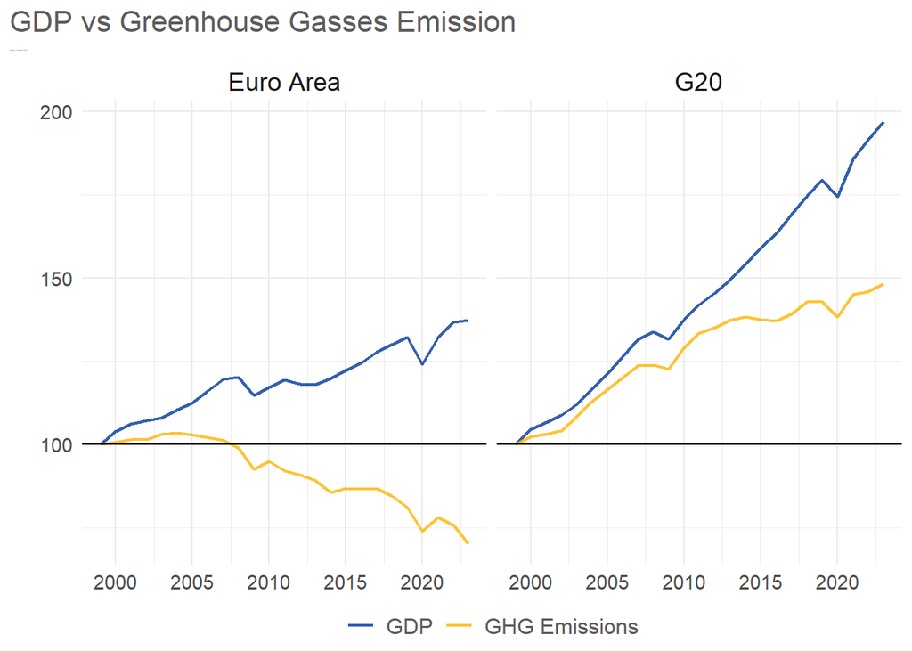

```r
col_patette=scale_color_manual(values = c("#003899","#FFB400"),labels=c("GDP","GHG Emissions"))

data_chart3%>%
  ggplot(mapping = aes(x=`Time period`,y=`Index value`,color = Index)) +
  geom_line(linewidth = 0.85,alpha =0.8)+
  geom_hline(yintercept=100)+

  ggtitle("GDP vs Greenhouse Gasses Emission", subtitle = "Index 1999=100")+
  theme_minimal()+
  theme(legend.position = "bottom",
        text = element_text(color = "#5C5C5C"),
        legend.title=element_blank(),
        legend.text = element_text(size=12),
        legend.margin = margin(t = -15),
        axis.title.y =element_text(size=15),
        axis.text=element_text(size=11),
        plot.title = element_text(size = 16),
        strip.text.x = element_text(size = 14),
        plot.subtitle = element_text(face= "italic",size = 1),
        plot.title.position = "plot",plot.caption.position ="plot" )+col_patette+
  xlim(c(1999,2023))+
  xlab("")+
  ylab("")+facet_wrap(~Country, scale="fixed")
```

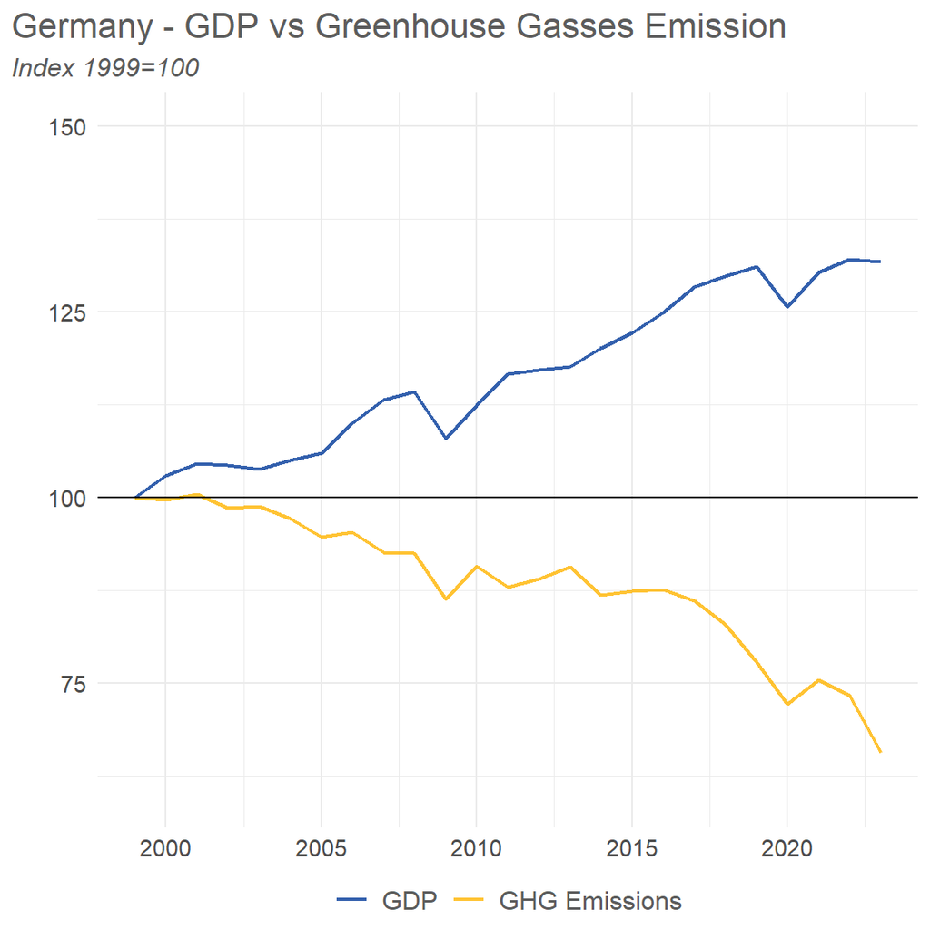

```r
final_data_granular_gdp%>%filter(Country=="Germany") %>%
  ggplot(mapping = aes(x=`Time period`,y=`Index value`,color = Index)) +
  geom_line(linewidth = 0.85,alpha =0.8)+
  geom_hline(yintercept=100)+

  ggtitle("Germany - GDP vs Greenhouse Gasses Emission", subtitle = "Index 1999=100")+
  theme_minimal()+
  theme(legend.position = "bottom",
        text = element_text(color = "#5C5C5C"),
        legend.title=element_blank(),
        legend.text = element_text(size=12),
        legend.margin = margin(t = -15),
        axis.title.y =element_text(size=15),
        axis.text=element_text(size=11),
        plot.title = element_text(size = 16),
        plot.subtitle = element_text(face= "italic",size = 12),
        plot.title.position = "plot",plot.caption.position ="plot" )+col_patette+
  xlim(c(1999,2023))+
  ylim(c(60,150))+
  xlab("")+
  ylab("")
```

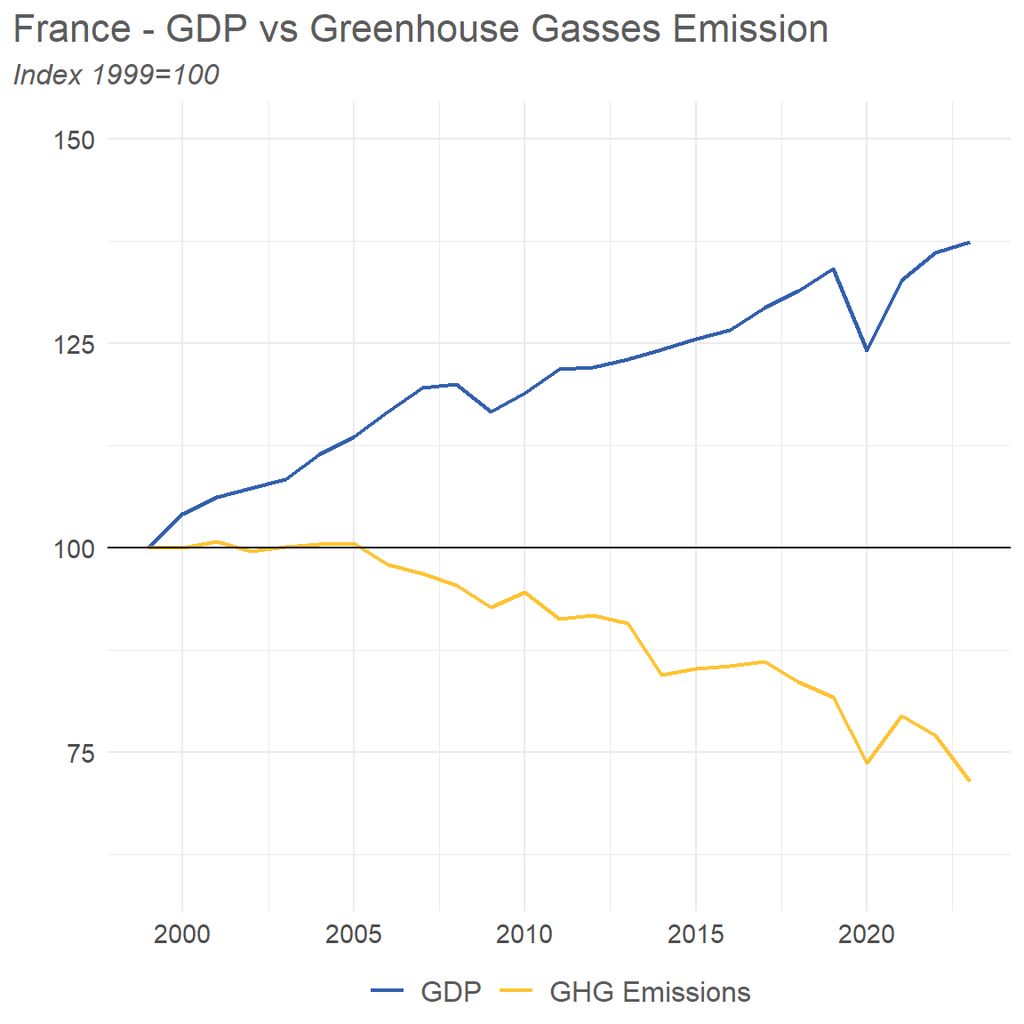

```r
final_data_granular_gdp%>%filter(Country=="France and Monaco") %>%
  ggplot(mapping = aes(x=`Time period`,y=`Index value`,color = Index)) +
  geom_line(linewidth = 0.85,alpha =0.8)+
  geom_hline(yintercept=100)+

  ggtitle("France - GDP vs Greenhouse Gasses Emission", subtitle = "Index 1999=100")+
  theme_minimal()+
  theme(legend.position = "bottom",
        text = element_text(color = "#5C5C5C"),
        legend.title=element_blank(),
        legend.text = element_text(size=12),
        legend.margin = margin(t = -15),
        axis.title.y =element_text(size=15),
        axis.text=element_text(size=11),
        plot.title = element_text(size = 16),
        plot.subtitle = element_text(face= "italic",size = 12),
        plot.title.position = "plot",plot.caption.position ="plot" )+col_patette+
  xlim(c(1999,2023))+
  ylim(c(60,150))+
  xlab("")+
  ylab("")
```

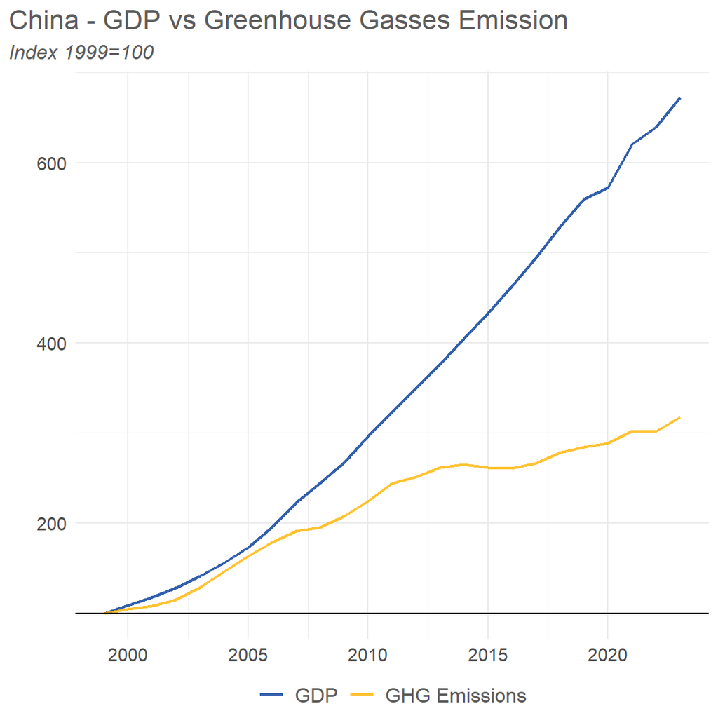

```r
final_data_granular_gdp%>%filter(Country=="China") %>%
  ggplot(mapping = aes(x=`Time period`,y=`Index value`,color = Index)) +
  geom_line(linewidth = 0.85,alpha =0.8)+
  geom_hline(yintercept=100)+

  ggtitle("China - GDP vs Greenhouse Gasses Emission", subtitle = "Index 1999=100")+
  theme_minimal()+
  theme(legend.position = "bottom",
        text = element_text(color = "#5C5C5C"),
        legend.title=element_blank(),
        legend.text = element_text(size=12),
        legend.margin = margin(t = -15),
        axis.title.y =element_text(size=15),
        axis.text=element_text(size=11),
        plot.title = element_text(size = 16),
        plot.subtitle = element_text(face= "italic",size = 12),
        plot.title.position = "plot",plot.caption.position ="plot" )+col_patette+
  xlim(c(1999,2023))+
  xlab("")+
  ylab("")
```

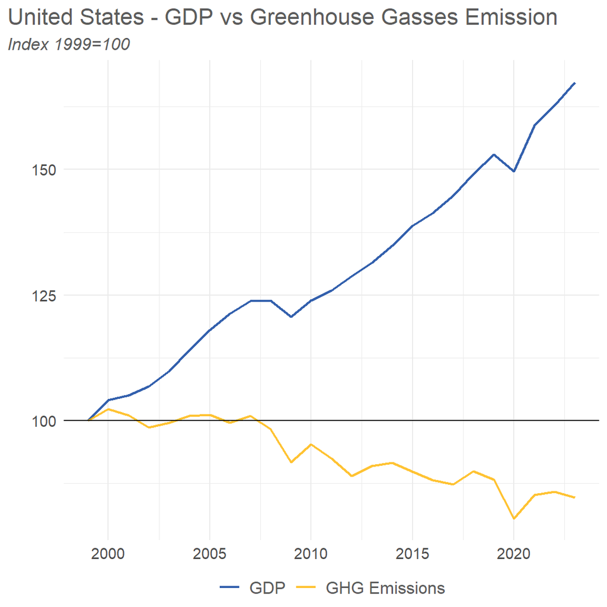

```r
final_data_granular_gdp%>%filter(Country=="United States") %>%
  ggplot(mapping = aes(x=`Time period`,y=`Index value`,color = Index)) +
  geom_line(linewidth = 0.85,alpha =0.8)+
  geom_hline(yintercept=100)+

  ggtitle("United States - GDP vs Greenhouse Gasses Emission", subtitle = "Index 1999=100")+
  theme_minimal()+
  theme(legend.position = "bottom",
        text = element_text(color = "#5C5C5C"),
        legend.title=element_blank(),
        legend.text = element_text(size=12),
        legend.margin = margin(t = -15),
        axis.title.y =element_text(size=15),
        axis.text=element_text(size=11),
        plot.title = element_text(size = 16),
        plot.subtitle = element_text(face= "italic",size = 12),
        plot.title.position = "plot",plot.caption.position ="plot" )+col_patette+
  xlim(c(1999,2023))+
  xlab("")+
  ylab("")
```

## Any other interesting insights that you may wish to share and its possible linkage with international developments

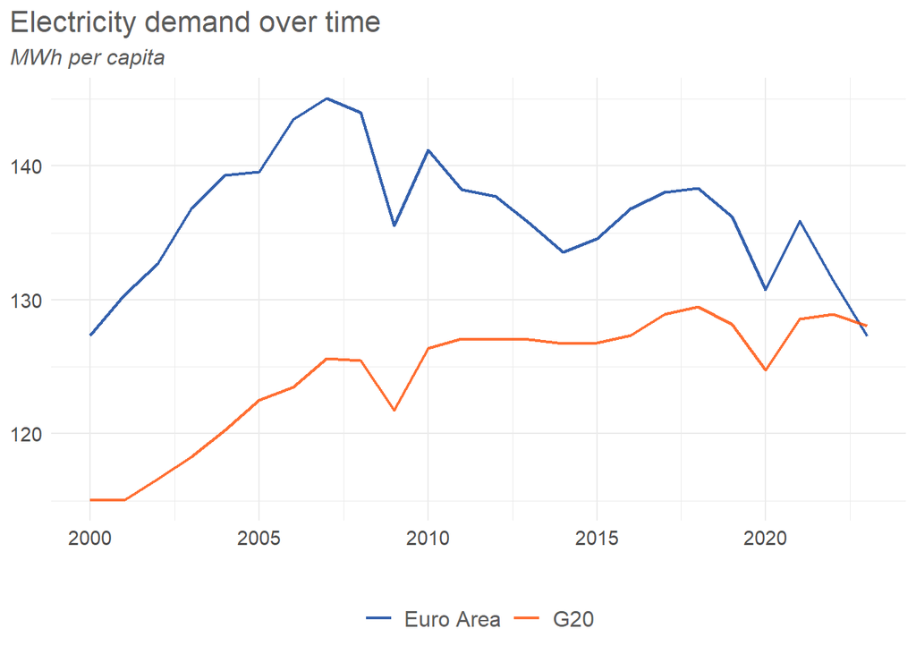

```r
energy_data=read.csv("./data/yearly_full_release_long_format.csv",header = T,check.names = F)

Electricity_demand_data <-energy_data %>%  filter(if_any(c(`EU`, `G20`), ~ . == 1)) %>% filter(Category %in% c("Electricity demand")) %>% filter(Variable %in% c("Demand per capita"))

Electricity_demand_data_g20=Electricity_demand_data %>% filter(G20 == 1 )  %>% group_by(`Year`, `Variable`) %>% mutate(Value=sum(Value)) %>% ungroup() %>% select(Year,Variable,Value) %>% mutate(Country="G20")
Electricity_demand_data_ea=Electricity_demand_data %>% filter(`Country code` %in% euro_area_countries_3letter  )  %>% group_by(`Year`, `Variable`) %>% mutate(Value=sum(Value)) %>% ungroup() %>% select(Year,Variable,Value) %>% mutate(Country="Euro Area")

rbind(Electricity_demand_data_g20, Electricity_demand_data_ea) %>%
ggplot(mapping = aes(x=`Year`,y=`Value`,color = Country)) +
  geom_line(linewidth = 0.85,alpha =0.8)+
  ggtitle("Electricity demand over time", subtitle = "MWh per capita")+
  theme_minimal()+
  theme(legend.position = "bottom",
        text = element_text(color = "#5C5C5C"),
        legend.title=element_blank(),
        legend.text = element_text(size=12),
        axis.title.y =element_blank(),
        axis.text=element_text(size=11),
        plot.title = element_text(size = 16),
        plot.subtitle = element_text(face= "italic",size = 12),
        plot.title.position = "plot",plot.caption.position ="plot" )+colScale1+
  xlim(c(2000,2023))+
  xlab("")+
  ylab("")
```

```r
cleaned__energy_data=energy_data %>%  filter(if_any(c(`EU`, `G20`), ~ . == 1)) %>% filter(Category %in% c("Electricity generation", "Power sector emissions")) %>% filter(Variable %in% c("Coal",'Gas and Other Fossil','Renewables','Nuclear')) %>% filter(Unit %in% c("%","mtCO2","TWh")) %>% select(-c(Subcategory,`Ember region`,Continent,`Area type`))

cleaned__energy_data=energy_data %>%  filter(if_any(c(`EU`, `G20`), ~ . == 1)) %>% filter(Category %in% c("Electricity generation", "Power sector emissions")) %>% filter(Variable %in% c("Coal",'Gas and Other Fossil','Renewables','Nuclear')) %>% filter(Unit %in% c("%","mtCO2","TWh")) %>% select(-c(Subcategory,`Ember region`,Continent,`Area type`))

colScale2=scale_fill_manual(values = c("#5C5C5C","#8139C6","#FFB400","#65b800"))
```

```r
a=cleaned__energy_data %>% filter(G20 == 1 ) %>% filter(`Unit` == "TWh") %>%filter(`Variable` == "Coal")   %>% group_by(`Year`, `Variable`) %>% mutate(Value=sum(Value)) %>% ungroup() %>% select(Year,Variable,Value) %>% distinct() %>% pull(Value)
b=data_chart3 %>% filter(`Country`=='G20') %>% filter(`Time period`>=2000)  %>% filter(`Index`=='GHG_index_1999') %>% pull(`GHG Total`
)
cor(a,b)
```

```
## [1] 0.99767
```

```r
cor.test(a,b)
```

```
##
##  Pearson's product-moment correlation
##
## data:  a and b
## t = 68.589, df = 22, p-value < 2.2e-16
## alternative hypothesis: true correlation is not equal to 0
## 95 percent confidence interval:
##  0.9945277 0.9990088
## sample estimates:
##     cor
## 0.99767
```

```r
a=cleaned__energy_data %>% filter(`Country code` %in% euro_area_countries_3letter ) %>% filter(`Unit` == "TWh") %>%filter(`Variable` == "Coal")   %>% group_by(`Year`, `Variable`) %>% mutate(Value=sum(Value)) %>% ungroup() %>% select(Year,Variable,Value) %>% distinct() %>% pull(Value)
b=data_chart3 %>% filter(`Country`=='Euro Area') %>% filter(`Time period`>=2000)  %>% filter(`Index`=='GHG_index_1999') %>% pull(`GHG Total`
)
cor(a,b)
```

```
## [1] 0.9376284
```

```r
cor.test(a,b)
```

```
##
##  Pearson's product-moment correlation
##
## data:  a and b
## t = 12.651, df = 22, p-value = 1.433e-11
## alternative hypothesis: true correlation is not equal to 0
## 95 percent confidence interval:
##  0.8592197 0.9730009
## sample estimates:
##       cor
## 0.9376284
```

```r
cleaned__energy_data %>% filter(G20 == 1 ) %>% filter(`Unit` == "TWh") %>% group_by(`Year`, `Variable`) %>% mutate(Value=sum(Value)) %>% ungroup() %>% select(Year,Variable,Value) %>% distinct() %>% group_by(`Year`) %>% mutate(`Production contribution`=Value/sum(Value)*100) %>% ungroup()
```

```
## # A tibble: 96 × 4
##     Year Variable             Value `Production contribution`
##    <int> <chr>                <dbl>                     <dbl>
##  1  2000 Gas and Other Fossil 2740.                      23.3
##  2  2000 Renewables           1907.                      16.2
##  3  2000 Coal                 5012.                      42.5
##  4  2000 Nuclear              2121.                      18.0
##  5  2001 Gas and Other Fossil 2793.                      23.5
##  6  2001 Renewables           1846.                      15.5
##  7  2001 Coal                 5069.                      42.7
##  8  2001 Nuclear              2174.                      18.3
##  9  2002 Gas and Other Fossil 2887.                      23.4
## 10  2002 Renewables           1931.                      15.7
## # ℹ 86 more rows
```

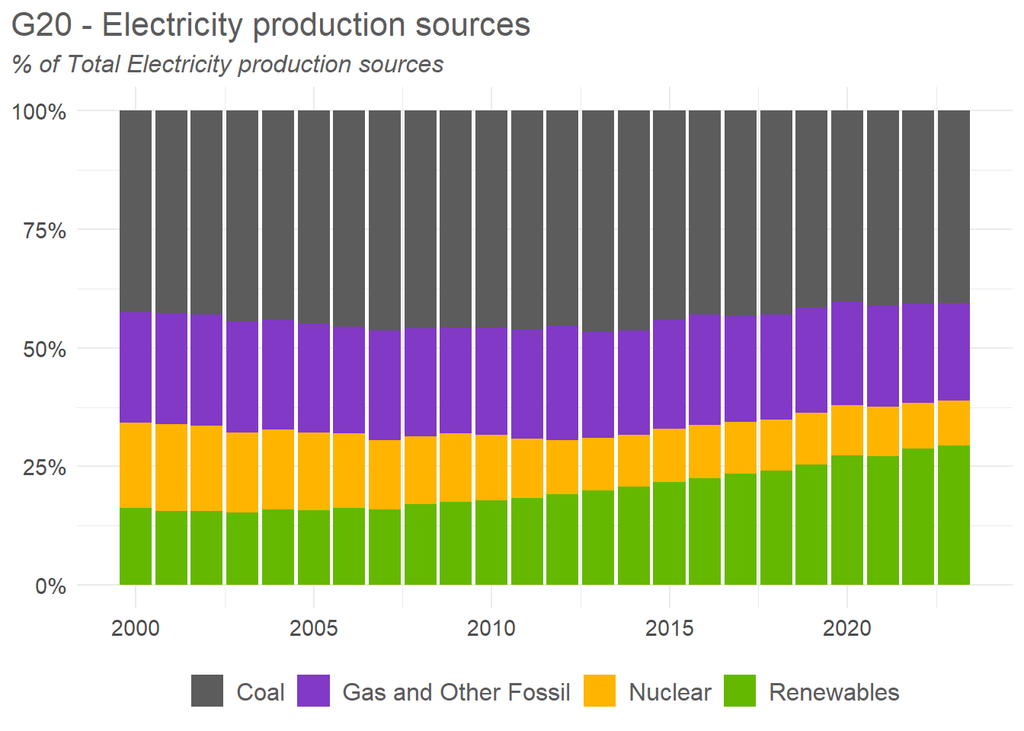

```r
cleaned__energy_data %>% filter(G20 == 1 ) %>% filter(`Unit` == "TWh") %>% group_by(`Year`, `Variable`) %>% mutate(Value=sum(Value)) %>% ungroup() %>% select(Year,Variable,Value) %>% distinct() %>% group_by(`Year`) %>% mutate(`Production contribution`=Value/sum(Value)*100) %>% ungroup()%>%
  ggplot(., aes(x = `Year`, y = `Production contribution`, fill = `Variable`)) +
  geom_bar(stat = "identity", position = "fill") +
  colScale2+
  scale_y_continuous(labels = scales::percent_format(accuracy = 1)) +
  labs(x = "Year", y = "Percentage Contribution", title = "G20 - Electricity production sources", subtitle = "% of Total Electricity production sources") +
    theme_minimal()+
  theme(legend.position = "bottom",
        text = element_text(color = "#5C5C5C"),
        legend.title=element_blank(),
        legend.text = element_text(size=12),
        axis.title.y =element_blank(),
        axis.title.x =element_blank(),
        axis.text=element_text(size=11),
        plot.title = element_text(size = 16),
        plot.subtitle = element_text(face= "italic",size = 12),
        plot.title.position = "plot",plot.caption.position ="plot" )
```

```r
cleaned__energy_data %>% filter(`Country code` %in% euro_area_countries_3letter ) %>% filter(`Unit` == "TWh") %>% group_by(`Year`, `Variable`) %>% mutate(Value=sum(Value)) %>% ungroup() %>% select(Year,Variable,Value) %>% distinct() %>% group_by(`Year`) %>% mutate(`Production contribution`=Value/sum(Value)*100) %>% ungroup()
```

```
## # A tibble: 96 × 4
##     Year Variable             Value `Production contribution`
##    <int> <chr>                <dbl>                     <dbl>
##  1  2000 Gas and Other Fossil  503.                      24.0
##  2  2000 Renewables            296.                      14.1
##  3  2000 Coal                  548.                      26.1
##  4  2000 Nuclear               751.                      35.8
##  5  2001 Gas and Other Fossil  523.                      24.3
##  6  2001 Renewables            325.                      15.1
##  7  2001 Coal                  538.                      25.0
##  8  2001 Nuclear               763.                      35.5
##  9  2002 Gas and Other Fossil  557.                      25.5
## 10  2002 Renewables            288.                      13.2
## # ℹ 86 more rows
```

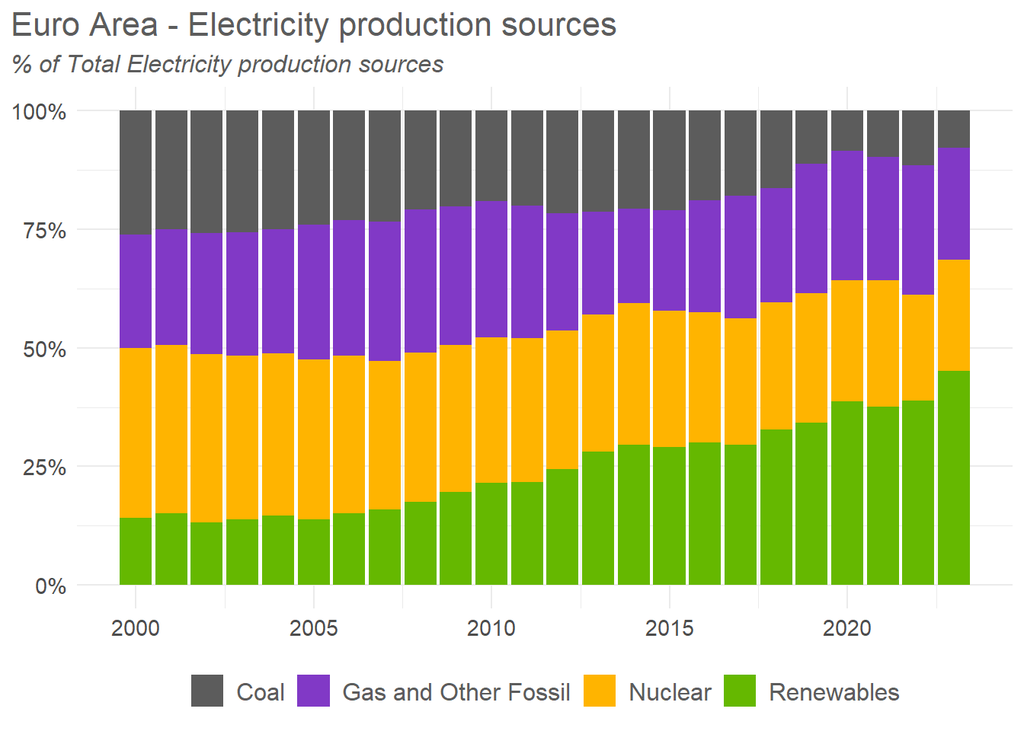

```r
cleaned__energy_data %>% filter(`Country code` %in% euro_area_countries_3letter ) %>% filter(`Unit` == "TWh") %>% group_by(`Year`, `Variable`) %>% mutate(Value=sum(Value)) %>% ungroup() %>% select(Year,Variable,Value) %>% distinct() %>% group_by(`Year`) %>% mutate(`Production contribution`=Value/sum(Value)*100) %>% ungroup()%>%
  ggplot(., aes(x = `Year`, y = `Production contribution`, fill = `Variable`)) +
  geom_bar(stat = "identity", position = "fill") +
  colScale2+
  scale_y_continuous(labels = scales::percent_format(accuracy = 1)) +
  labs(x = "Year", y = "Percentage Contribution", title = "Euro Area - Electricity production sources", subtitle = "% of Total Electricity production sources") +
    theme_minimal()+
  theme(legend.position = "bottom",
        text = element_text(color = "#5C5C5C"),
        legend.title=element_blank(),
        legend.text = element_text(size=12),
        axis.title.y =element_blank(),
        axis.title.x =element_blank(),
        axis.text=element_text(size=11),
        plot.title = element_text(size = 16),
        plot.subtitle = element_text(face= "italic",size = 12),
        plot.title.position = "plot",plot.caption.position ="plot" )
```

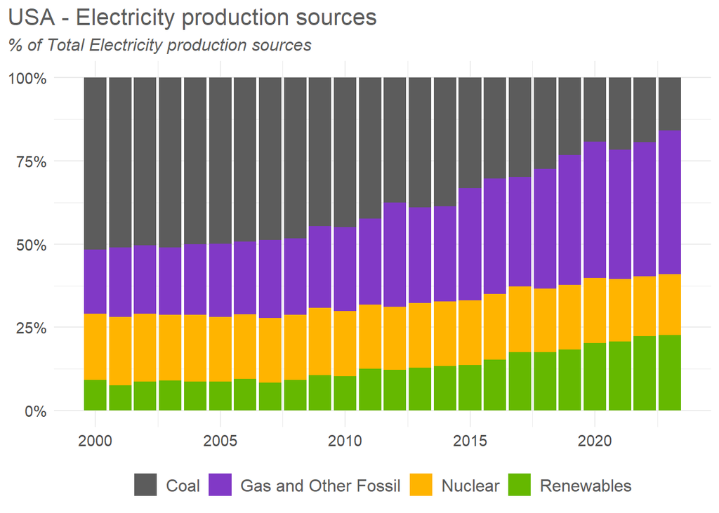

```r
cleaned__energy_data %>% filter(`Country code` == 'USA' ) %>% filter(`Unit` == "TWh") %>% group_by(`Year`, `Variable`) %>% mutate(Value=sum(Value)) %>% ungroup() %>% select(Year,Variable,Value) %>% distinct() %>% group_by(`Year`) %>% mutate(`Production contribution`=Value/sum(Value)*100) %>% ungroup()%>%
  ggplot(., aes(x = `Year`, y = `Production contribution`, fill = `Variable`)) +
  geom_bar(stat = "identity", position = "fill") +
  colScale2+
  scale_y_continuous(labels = scales::percent_format(accuracy = 1)) +
  labs(x = "Year", y = "Percentage Contribution", title = "USA - Electricity production sources",subtitle = "% of Total Electricity production sources") +
    theme_minimal()+
  theme(legend.position = "bottom",
        text = element_text(color = "#5C5C5C"),
        legend.title=element_blank(),
        legend.text = element_text(size=12),
        axis.title.y =element_blank(),
        axis.title.x =element_blank(),
        axis.text=element_text(size=11),
        plot.title = element_text(size = 16),
        plot.subtitle = element_text(face= "italic",size = 12),
        plot.title.position = "plot",plot.caption.position ="plot" )
```

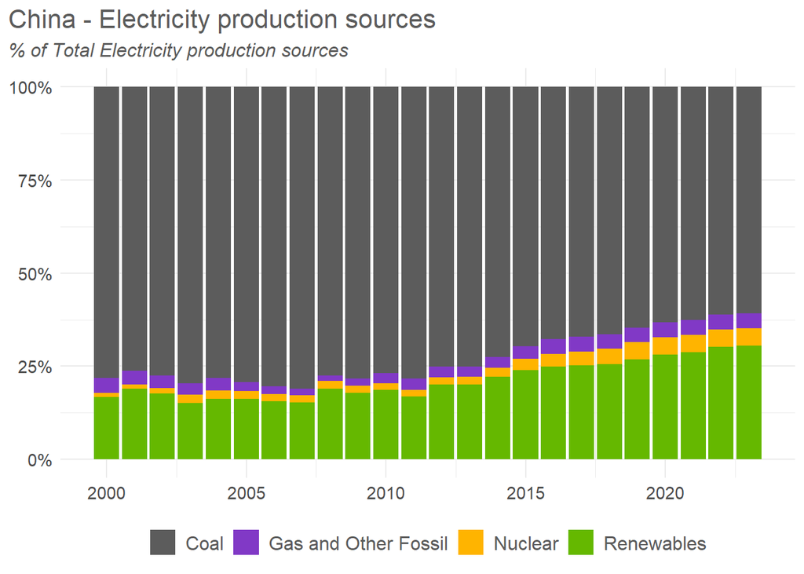

```r
cleaned__energy_data %>% filter(`Country code` == 'CHN' ) %>% filter(`Unit` == "TWh") %>% group_by(`Year`, `Variable`) %>% mutate(Value=sum(Value)) %>% ungroup() %>% select(Year,Variable,Value) %>% distinct() %>% group_by(`Year`) %>% mutate(`Production contribution`=Value/sum(Value)*100) %>% ungroup()%>%
  ggplot(., aes(x = `Year`, y = `Production contribution`, fill = `Variable`)) +
  geom_bar(stat = "identity", position = "fill") +
  scale_y_continuous(labels = scales::percent_format(accuracy = 1)) +
  colScale2+
  labs(x = "Year", y = "Percentage Contribution", title = "China - Electricity production sources",subtitle = "% of Total Electricity production sources") +
  theme_minimal()+
  theme(legend.position = "bottom",
        text = element_text(color = "#5C5C5C"),
        legend.title=element_blank(),
        legend.text = element_text(size=12),
        axis.title.y =element_blank(),
        axis.title.x =element_blank(),
        axis.text=element_text(size=11),
        plot.title = element_text(size = 16),
        plot.subtitle = element_text(face= "italic",size = 12),
        plot.title.position = "plot",plot.caption.position ="plot" )
```

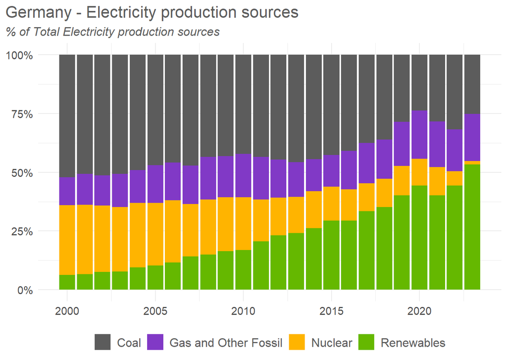

```r
cleaned__energy_data %>% filter(`Country code` == 'DEU' ) %>% filter(`Unit` == "TWh") %>% group_by(`Year`, `Variable`) %>% mutate(Value=sum(Value)) %>% ungroup() %>% select(Year,Variable,Value) %>% distinct() %>% group_by(`Year`) %>% mutate(`Production contribution`=Value/sum(Value)*100) %>%
  ungroup()%>%
  ggplot(., aes(x = `Year`, y = `Production contribution`, fill = `Variable`)) +
  geom_bar(stat = "identity", position = "fill") +
  scale_y_continuous(labels = scales::percent_format(accuracy = 1)) +
  colScale2+
  labs(x = "Year", y = "Percentage Contribution", title = "Germany - Electricity production sources", subtitle = "% of Total Electricity production sources") +
  theme_minimal()+
  theme(legend.position = "bottom",
        text = element_text(color = "#5C5C5C"),
        legend.title=element_blank(),
        legend.text = element_text(size=12),
        axis.title.y =element_blank(),
        axis.title.x =element_blank(),
        axis.text=element_text(size=11),
        plot.title = element_text(size = 16),
        plot.subtitle = element_text(face= "italic",size = 12),
        plot.title.position = "plot",plot.caption.position ="plot" )
```